# analysis

# Preamble: Packages & global options

Loading necessary packages:

```r
rm(list = ls())
library(ggplot2)
library(dplyr)
library(tidyr)
library(aida)
library(broom)
library(MASS)
library(brms)
library(cmdstanr)
library(cspplot) # https://github.com/CogSciPrag/cspplot
```

Setting some global options:

```r
# these options help Stan run faster
options(mc.cores = parallel::detectCores(),
        brms.backend = "cmdstanr")

# use the CSP-theme for plotting
theme_set(theme_csp())

# global color scheme from CSP
project_colors = cspplot::list_colors() |> pull(hex)

# setting theme colors globally
scale_colour_discrete <- function(...) {
  scale_colour_manual(..., values = project_colors)
}
scale_fill_discrete <- function(...) {
  scale_fill_manual(..., values = project_colors)
}
```

# Data inspection & preprocessing

## Load data

```r
data <- read.csv("../../data/data_listenerside/data_pilot1.csv")
```

## Basic data

### Participants info

```r
# How many participants do we have?
num_participants <- data %>% distinct(submission_id)
print("We have the following number of participants:")
```

```
## [1] "We have the following number of participants:"
```

```r
nrow(num_participants)
```

```
## [1] 50
```

## Descriptive data analysis

```r
experiment_condition <- c("low", "info", "high")

# Filter out NA data and sample trial data
data <- data %>%
  mutate(condition = factor(condition, levels = experiment_condition)) %>%
  filter(!is.na(response)) %>%
  filter(condition %in% experiment_condition)

# Encode the responses into conditions
response_code <- c(
  "Student"   = "low",
  "Teacher"   = "high",
  "Principal" = "info"
)

data <- data %>%
  mutate(
    response_condition = response_code[response],
    response_condition = factor(response_condition,
                                levels = experiment_condition)
  )

# Compute count and proportions by condition
descriptive_summary <- data %>%
  group_by(condition, response_condition) %>%
  summarise(
    n = n(),
    .groups = "drop"
  ) %>%
  group_by(condition) %>%
  mutate(
    proportion = n / sum(n)
  ) %>%
  ungroup()

descriptive_summary
```

```
## # A tibble: 9 × 4
##   condition response_condition     n proportion
##   <fct>     <fct>              <int>      <dbl>
## 1 low       low                  136      0.544
## 2 low       info                  79      0.316
## 3 low       high                  35      0.14
## 4 info      low                   71      0.284
## 5 info      info                  77      0.308
## 6 info      high                 102      0.408
## 7 high      low                   43      0.172
## 8 high      info                  54      0.216
## 9 high      high                 153      0.612
```

```r
descriptive_wide <- descriptive_summary %>%
  dplyr::select(condition, response_condition, proportion) %>%
  pivot_wider(
    names_from  = response_condition,
    values_from = proportion,
    values_fill = 0
  )

descriptive_wide
```

```
## # A tibble: 3 × 4
##   condition   low  info  high
##   <fct>     <dbl> <dbl> <dbl>
## 1 low       0.544 0.316 0.14
## 2 info      0.284 0.308 0.408
## 3 high      0.172 0.216 0.612
```

Sanity check.

```r
# all responses mapped?
sum(is.na(data$response_condition))
```

```
## [1] 0
```

```r
# proportions sum to 1?
descriptive_summary %>%
  group_by(condition) %>%
  summarise(sum_prop = sum(proportion))
```

```
## # A tibble: 3 × 2
##   condition sum_prop
##   <fct>        <dbl>
## 1 low              1
## 2 info             1
## 3 high             1
```

```r
# Helper for bootstrapping
bootstrap_props_one_condition <- function(df, B = 2000, level = 0.95) {
  # Ensure factor with stable levels
  res_levels <- levels(df$response_condition)
  if (is.null(res_levels)) {
    res_levels <- sort(unique(df$response_condition))
    df <- df %>% mutate(response_condition = factor(response_condition,
                                                    levels = res_levels))
  }

  boot_mat <- replicate(B, {
    idx <- sample(seq_len(nrow(df)), replace = TRUE)
    tab <- table(df$response_condition[idx])
    # ensure all levels present
    tab_full <- tab[res_levels]
    tab_full[is.na(tab_full)] <- 0
    as.numeric(tab_full) / length(idx)
  })

  alpha <- (1 - level) / 2
  ci_low  <- apply(boot_mat, 1, quantile, probs = alpha)
  ci_high <- apply(boot_mat, 1, quantile, probs = 1 - alpha)
  prop_emp <- as.numeric(table(df$response_condition)[res_levels]) / nrow(df)

  tibble(
    response_condition = factor(res_levels, levels = res_levels),
    proportion         = prop_emp,
    ci_low             = ci_low,
    ci_high            = ci_high
  )
}

# Bootstrap proportions with CIs by condition
boot_descriptive <- data %>%
  group_by(condition) %>%
  group_modify(~ bootstrap_props_one_condition(.x)) %>%
  ungroup()

boot_descriptive
```

```
## # A tibble: 9 × 5
##   condition response_condition proportion ci_low ci_high
##   <fct>     <fct>                   <dbl>  <dbl>   <dbl>
## 1 low       low                     0.544  0.484   0.604
## 2 low       info                    0.316  0.26    0.376
## 3 low       high                    0.14   0.1     0.188
## 4 info      low                     0.284  0.228   0.34
## 5 info      info                    0.308  0.252   0.368
## 6 info      high                    0.408  0.352   0.468
## 7 high      low                     0.172  0.128   0.22
## 8 high      info                    0.216  0.168   0.268
## 9 high      high                    0.612  0.552   0.676
```

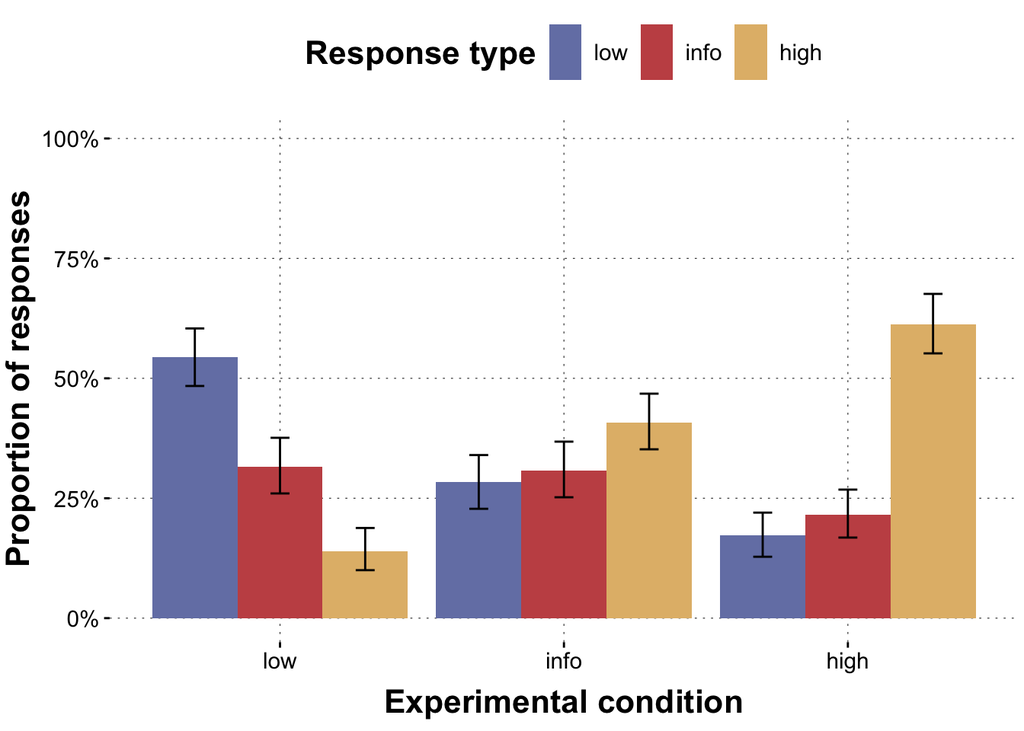

```r
# Plot descriptive proportions with CIs
ggplot(boot_descriptive,
       aes(x = condition,
           y = proportion,
           fill = response_condition)) +
  geom_col(position = position_dodge(width = 0.9)) +
  geom_errorbar(
    aes(ymin = ci_low, ymax = ci_high),
    position = position_dodge(width = 0.9),
    width = 0.2
  ) +
  scale_y_continuous(labels = scales::percent_format(accuracy = 1),
                     limits = c(0, 1)) +
  labs(
    x = "Experimental condition",
    y = "Proportion of responses",
    fill = "Response type"
  ) +
  theme_aida()
```

## Inferential data analysis

First we try with GLM based analysis. We could for each conditions enocode fit and non-fit.

```r
# 1. Fit vs non-fit per trial
data <- data %>%
  mutate(
    fit = if_else(condition == response_condition, 1L, 0L),
    # set reference level (change if you prefer another baseline)
    condition = relevel(condition, ref = "info")
  )

# 2. Descriptive proportions of 'fit' by condition
fit_summary <- data %>%
  group_by(condition) %>%
  summarise(
    n      = n(),
    n_fit  = sum(fit),
    prop_fit = n_fit / n,
    .groups = "drop"
  )

fit_summary
```

```
## # A tibble: 3 × 4
##   condition     n n_fit prop_fit
##   <fct>     <int> <int>    <dbl>
## 1 info        250    77    0.308
## 2 low         250   136    0.544
## 3 high        250   153    0.612
```

```r
# Logistic regression: fit ~ condition
glm_fit <- glm(fit ~ condition,
               data   = data,
               family = binomial)

summary(glm_fit)
```

```
##
## Call:
## glm(formula = fit ~ condition, family = binomial, data = data)
##
## Coefficients:
##               Estimate Std. Error z value Pr(>|z|)
## (Intercept)    -0.8095     0.1370  -5.909 3.44e-09 ***
## conditionlow    0.9859     0.1868   5.278 1.30e-07 ***
## conditionhigh   1.2652     0.1887   6.704 2.02e-11 ***
## ---
## Signif. codes:  0 '***' 0.001 '**' 0.01 '*' 0.05 '.' 0.1 ' ' 1
##
## (Dispersion parameter for binomial family taken to be 1)
##
##     Null deviance: 1039.3  on 749  degrees of freedom
## Residual deviance:  987.3  on 747  degrees of freedom
## AIC: 993.3
##
## Number of Fisher Scoring iterations: 4
```

```r
# Odds ratios with 95% CIs
glm_fit_or <- tidy(glm_fit,
                   conf.int   = TRUE,
                   exponentiate = TRUE)

glm_fit_or
```

```
## # A tibble: 3 × 7
##   term          estimate std.error statistic  p.value conf.low conf.high
##   <chr>            <dbl>     <dbl>     <dbl>    <dbl>    <dbl>     <dbl>
## 1 (Intercept)      0.445     0.137     -5.91 3.44e- 9    0.339     0.580
## 2 conditionlow     2.68      0.187      5.28 1.30e- 7    1.86      3.88
## 3 conditionhigh    3.54      0.189      6.70 2.02e-11    2.46      5.15
```

Next we try with binomial test:

```r
chance <- 1/3

fit_tests <- fit_summary %>%
  rowwise() %>%
  mutate(
    bt = list(binom.test(n_fit, n, p = chance)),
    p_value  = bt$p.value,
    ci_low   = bt$conf.int[1],
    ci_high  = bt$conf.int[2]
  ) %>%
  ungroup() %>%
  dplyr::select(condition, n, n_fit, prop_fit, p_value, ci_low, ci_high)

fit_tests
```

```
## # A tibble: 3 × 7
##   condition     n n_fit prop_fit  p_value ci_low ci_high
##   <fct>     <int> <int>    <dbl>    <dbl>  <dbl>   <dbl>
## 1 info        250    77    0.308 4.21e- 1  0.251   0.369
## 2 low         250   136    0.544 9.16e-12  0.480   0.607
## 3 high        250   153    0.612 2.57e-19  0.549   0.673
```

Finally we will try an ordinal logit regression analysis:

```r
# Make sure factors are set up correctly
data <- data %>%
  mutate(
    # ordered outcome for brms
    response_ord = factor(
      response_condition,
      levels = c("low", "info", "high"),
      ordered = TRUE
    ),
    # set baseline of condition
    condition = relevel(condition, ref = "info")
  )

table(data$response_ord, data$condition)
```

```
##
##        info low high
##   low    71 136   43
##   info   77  79   54
##   high  102  35  153
```

```r
# Priors: fairly weakly informative
priors <- c(
  set_prior("normal(0, 2)", class = "b"),         # effects of condition
  set_prior("normal(0, 5)", class = "Intercept")  # thresholds (cut-points)
)

ord_brms <- brm(
  formula = response_ord ~ condition,
  family  = cumulative("logit"),
  data    = data,
  prior   = priors,
  chains  = 4,
  iter    = 4000,
  warmup  = 2000,
  cores   = 4,
  seed    = 1234,
  backend = "cmdstanr"
)
```

```r
summary(ord_brms)
```

[output not shown]

```r
fixef(ord_brms)  # raw posterior summaries on log-odds scale
```

```
##                 Estimate Est.Error       Q2.5      Q97.5
## Intercept[1]  -0.9565321 0.1263570 -1.2061140 -0.7119381
## Intercept[2]   0.3936822 0.1221678  0.1520091  0.6300075
## conditionlow  -1.1967460 0.1690025 -1.5312812 -0.8736874
## conditionhigh  0.8013716 0.1734572  0.4605664  1.1347480
```

```r
# Exponentiate to get odds ratios
fixef_ord_or <- exp(fixef(ord_brms)[, c("Estimate", "Q2.5", "Q97.5")])
fixef_ord_or
```

```
##                Estimate      Q2.5     Q97.5
## Intercept[1]  0.3842230 0.2993583 0.4906923
## Intercept[2]  1.4824293 1.1641709 1.8776248
## conditionlow  0.3021759 0.2162584 0.4174096
## conditionhigh 2.2285956 1.5849715 3.1103896
```

```r
new_dat <- data.frame(
  condition = factor(c("info", "high", "low"),
                     levels = levels(data$condition))
)

pred_probs <- fitted(
  ord_brms,
  newdata = new_dat,
  summary = TRUE  # average across posterior draws
)

pred_probs
```

```
## , , P(Y = low)
##
##       Estimate  Est.Error      Q2.5     Q97.5
## [1,] 0.2782820 0.02527715 0.2303894 0.3291707
## [2,] 0.1479780 0.01821726 0.1142040 0.1864249
## [3,] 0.5595442 0.03012279 0.5014336 0.6188304
##
## , , P(Y = info)
##
##       Estimate  Est.Error      Q2.5     Q97.5
## [1,] 0.3185405 0.01883000 0.2818754 0.3551379
## [2,] 0.2518965 0.01933040 0.2147174 0.2899354
## [3,] 0.2702589 0.01882324 0.2341618 0.3072239
##
## , , P(Y = high)
##
##       Estimate  Est.Error      Q2.5     Q97.5
## [1,] 0.4031775 0.02930041 0.3475088 0.4620707
## [2,] 0.6001256 0.03110129 0.5400021 0.6609682
## [3,] 0.1701969 0.01930187 0.1341866 0.2093191
```

# Alternative Bayesian data analysis

## Conjunctive hypothesis testing with Bayesian multinomial model

The main prediction we have is that answer category `X` should be the modal choice in condition `X`. For `X` to be the modal choice means to be more frequently chosen than any other option `Y`. Since there are three choice options in each condition, we essentially deal with a *conjunctive hypothesis*, namely that `X > Y1` *and* `X > Y2`. Concretely, we want to test the following three hypotheses:

1. in condition `low`, answer category `low` is more likely than either of the two others
2. in condition `info`, answer category `info` is more likely than either of the two others
3. in condition `high`, answer category `high` is more likely than either of the two others

To do this, we run a single Bayesian model with `brms` and then compute the posterior probabilities of the above hypotheses based on samples from the posterior distribution.

```r
# code the data as 'match', 'non-match-1', 'non-match-2', depending on whether
# the response matches the condition or not
data_brm <-  data |>
  mutate(condition = relevel(condition, ref = "low"),
         response_condition = case_when(
           response_condition == condition  ~ "match",
           response_condition == "low"  & condition == "info"  ~ "non-match-1",
           response_condition == "low"  & condition == "high"  ~ "non-match-2",
           response_condition == "info" & condition == "low"   ~ "non-match-1",
           response_condition == "info" & condition == "high"  ~ "non-match-2",
           response_condition == "high" & condition == "info"  ~ "non-match-1",
           response_condition == "high" & condition == "low"   ~ "non-match-2"
         ))
```

```r
# run a multinomial Bayesian regression model with by-subjects random intercepts and slopes
fit <- brm(
  formula = response_condition ~ condition + (1 + condition | submission_id),
  family  = categorical(),
  data    = data_brm,
  chains  = 4,
  iter    = 4000,
  warmup  = 2000,
  backend = "cmdstanr"
)
```

Next, we extract posterior samples using the `tidybayes::add_epred_draws` function, which gives us samples from the posterior distribution of the expected values of the each response category for each condition. Then we extract the relevant posterior probabilities of the conjunctive hypotheses by computing the proportion of posterior samples in which the `match` category is more likely than both `non-match-1` and `non-match-2`.

```r
data_brm |>
  dplyr::select(condition) |>
  unique() |>
  tidybayes::add_epred_draws(
    fit,
    ndraws = 8000,
    allow_new_levels = TRUE
    ) |>
  pivot_wider (
    names_from = .category,
    values_from = .epred
  ) |>
  group_by(condition) |>
  summarize(
    post_prob_hypothesis = mean(match > `non-match-1` & match > `non-match-2`)
  )
```

```
## # A tibble: 3 × 2
##   condition post_prob_hypothesis
##   <fct>                    <dbl>
## 1 low                     0.756
## 2 info                    0.0789
## 3 high                    0.706
```

## More focused analysis: modal responses vs their predicted opposites

As a more focused analysis, we also look at whether participants pick the modal response option in conditions `low` and `high` more often than the opposite option, which is `high` in condition `low` and `low` in condition `high`. To do this, we do *not* filter the data to only include trials in conditions `low` and `high`, but reuse the full model (with random effects), but we just hone in on what we predict to be the more pronounced contrasts:

```r
data_brm |>
  dplyr::select(condition) |>
  unique() |>
  tidybayes::add_epred_draws(
    fit,
    ndraws = 8000,
    allow_new_levels = TRUE
    ) |>
  pivot_wider (
    names_from = .category,
    values_from = .epred
  ) |>
  filter(condition != "info") |>
  group_by(condition) |>
  summarize(
    post_prob_hypothesis = mean(match > `non-match-2`)
  )
```

```
## # A tibble: 2 × 2
##   condition post_prob_hypothesis
##   <fct>                    <dbl>
## 1 low                      0.934
## 2 high                     0.710
```